# ML_Notebook

- Comp47350 - Data Analytics
- Homework2
- This Report focuses on training and evaluating prediction models for a particular problem and dataset. In this analysis, we focus on using data collected by CDC to build a data analytics solution for death risk prediction.
- The goal of this report is to work with CDC data to build and evaluate prediction models that capture the relationship between the Independent Variables and the target feature **death_yn**.
- The Covid-19 pandemic caused widespread health and economic issues, primarily from 2020 until 2022. The Centre for Disease Control (CDC) in the USA has made public their Covid-19 data. The CDC database contains 105 million entries. From this, 50,000 datapoints were randomly selected for data analysis, with 19 features describing the data. The outcome for the target feature “death_yn” is known (i.e., either “yes” or “no”). The CDC dataset was in CSV format, and was parsed with Python 3.11.7 code.
- Each entry represents a different person, including information such as state and county of residence, age group, sex, race and whether the patient died as a result of illness, among others.
- The dataset has been cleaned prior. Of the original 19 features, 8 remain: case_month, res_state, age_group, sex, race, ethnicity, hosp_yn, and the target feature death_yn. Feature county_fips_code was transformed into county_frequency_size, and 3 additional features were created for the dataset: party, Profile, and seasons. The dataset, "new_features_df1.csv" contains 11 independent variables and the dependent variable, death_yn.
- In advance of the discussion that follows, it should be noted, the CDC database of the USA has 105,000,000 cases of Covid-19, and a death count of 1,143,724 as of late 2023 (https://www.cdc.gov/nchs/covid19/mortality-overview.htm). This means that Covid-19 has a rough mortality of 1.089% of those who contracted it, and this is a similar rate to that reported by the WHO (0.91%) (https://data.who.int/dashboards/covid19/cases?n=c). Given this data, features with frequencies which appear to be higher or lower than this rate could be good predictors for the target variable. The dataset which was first cleaned for use here contained a death/ survival rate of 1:4. 10,000 people in the dataset were confirmed deceased and 40,000 were confirmed survived.

```python
import pandas as pd
import matplotlib.pyplot as plt
from sklearn.linear_model import LinearRegression, LogisticRegression
from sklearn.metrics import accuracy_score, confusion_matrix, precision_score, recall_score, f1_score
from sklearn.ensemble import RandomForestClassifier, StackingClassifier
from sklearn.model_selection import cross_val_score, KFold, train_test_split, cross_val_predict
from sklearn.preprocessing import OneHotEncoder, StandardScaler
from sklearn.compose import ColumnTransformer
from sklearn.pipeline import Pipeline
from sklearn.feature_selection import RFE
import scipy.stats as stats
```

- Information from "Profile" is contained in other features. It was created for the previous assignment to find key demographs, but will interfere with accurate modelling in this assignment ( multicolinnearity concerns)
- The same is true for "season" and case_month, and case_month will be dropped

```python
df = pd.read_csv(r"C:\Users\35385\Desktop\CS_Spring2024\DataAnal\Homework2\new_features_df1.csv", keep_default_na=True, delimiter=",", skipinitialspace=True, encoding="Windows-1252")
df.drop(columns=["Profile", "case_month"], inplace=True)
```

```python
df[df.select_dtypes(['object']).columns] = df.select_dtypes(['object']).astype('category')
df.info()
```

```
<class 'pandas.core.frame.DataFrame'>
RangeIndex: 39947 entries, 0 to 39946
Data columns (total 10 columns):
 #   Column                 Non-Null Count  Dtype
---  ------                 --------------  -----
 0   res_state              39947 non-null  category
 1   age_group              39947 non-null  category
 2   sex                    39947 non-null  category
 3   race                   39947 non-null  category
 4   ethnicity              39947 non-null  category
 5   hosp_yn                39947 non-null  category
 6   death_yn               39947 non-null  category
 7   county_frequency_size  39947 non-null  category
 8   party                  39947 non-null  category
 9   seasons                39947 non-null  category
dtypes: category(10)
memory usage: 393.1 KB
```

```python
df.head(10)
```

|  | res_state | age_group | sex | race | ethnicity | hosp_yn | death_yn | county_frequency_size | party | seasons |
| --- | --- | --- | --- | --- | --- | --- | --- | --- | --- | --- |
| 0 | CA | 65+ years | _M | White | Non_H/L | Yes | Yes | Medium | DEMOCRAT | Spring |
| 1 | NY | 65+ years | _F | White | Non_H/L | Yes | Yes | Medium | DEMOCRAT | Spring |
| 2 | FL | 65+ years | _F | White | Non_H/L | No | Yes | Medium | DEMOCRAT | Fall |
| 3 | TX | 50 to 64 years | _M | White | H/L | Yes | Yes | Very_Large | DEMOCRAT | Summer |
| 4 | AZ | 65+ years | _M | White | H/L | Yes | Yes | Small | DEMOCRAT | Winter |
| 5 | WI | 65+ years | _F | White | Non_H/L | Yes | Yes | Medium | REPUBLICAN | Fall |
| 6 | MD | 65+ years | _F | White | Non_H/L | No | Yes | Small | DEMOCRAT | Spring |
| 7 | MN | 65+ years | _M | White | Non_H/L | No | Yes | Small | DEMOCRAT | Fall |
| 8 | NY | 65+ years | _M | White | Non_H/L | No | Yes | Huge | DEMOCRAT | Winter |
| 9 | NY | 65+ years | _F | White | Non_H/L | No | Yes | Huge | DEMOCRAT | Spring |

Frequency Table printed to better understand the dataset.

```python
for column in df.columns:
    print(f"Frequency table for column '{column}':")
    print(df[column].value_counts())
    print("\n")
```

```
Frequency table for column 'res_state':
res_state
NY    5301
NC    3759
NJ    3627
FL    3503
OH    2156
TX    2063
IN    2038
MN    2031
CA    1457
MD    1404
AZ    1113
MI    1109
KY     823
PA     785
KS     777
WI     650
VA     647
NV     618
OR     607
SC     599
UT     547
MA     538
IL     437
TN     394
OK     388
ID     301
CO     282
ME     280
DC     274
AL     206
AR     195
RI     161
MT     119
CT     115
WA     114
NH     109
MO      98
NM      76
```

[output cut: 70 more lines]

```

Frequency table for column 'party':
party
DEMOCRAT      26784
REPUBLICAN    13163
Name: count, dtype: int64


Frequency table for column 'seasons':
seasons
Winter    16414
Fall       9380
Summer     7237
Spring     6916
Name: count, dtype: int64
```

- **Data Understanding and Preparation:**
- The following section explores the relationships between feature pairs, followed by selecting/transforming promising features based on a given training set.
- The dataframe is divided in two: a 70% training set and 30% test set. The test set will be used later for analysis,
- The features in the training set are then plotted for their pairwise interactions with the target feature. Only values with a count of greater than 200 for a given feature are plotted, for ease of legibility in the graphs, especially for res_state and Profile features
- A subset of categorical features which look promising will be chosen for in-depth discussion and analysis. These will be features where it appears that there is a significant variance across the feature for predicting the target outcome, features for which there appears to be a trend for predicting death_yn etc.
- (1.1) Split the dataset into two datasets: 70% training and 30% test

```python
X = df.drop(columns=['death_yn'])
y = df['death_yn']
y = y.replace({'No': 0, 'Yes': 1})

# Split dataset into training and test sets; random_state ensuring the same test/ training datasets.
X_train, X_test, y_train, y_test = train_test_split(X, y, test_size=0.3, random_state=1)
print("Training data:\n", pd.concat([X_train, y_train], axis=1))
print("\nTest data:\n", pd.concat([X_test, y_test], axis=1))
```

```
Training data:
       res_state       age_group sex   race ethnicity hosp_yn  \
36228        IN  50 to 64 years  _M  White   Non_H/L      No
11671        OR  50 to 64 years  _M  White   Non_H/L      No
12993        KY       65+ years  _M  White   Non_H/L      No
17552        MI  50 to 64 years  _M  White   Non_H/L      No
4017         WA       65+ years  _F  White   Non_H/L      No
...         ...             ...  ..    ...       ...     ...
7813         MN       65+ years  _F  White   Non_H/L     Yes
32511        UT  18 to 49 years  _F  White   Non_H/L      No
5192         AZ       65+ years  _F  White   Non_H/L     Yes
12172        NC  18 to 49 years  _M  White   Non_H/L      No
33003        NY  18 to 49 years  _F  White   Non_H/L      No

      county_frequency_size       party seasons death_yn
```

[output cut: 42 more lines]

- (1.2) On the training set, for each categorical feature, plot its pairwise interaction with the target feature.

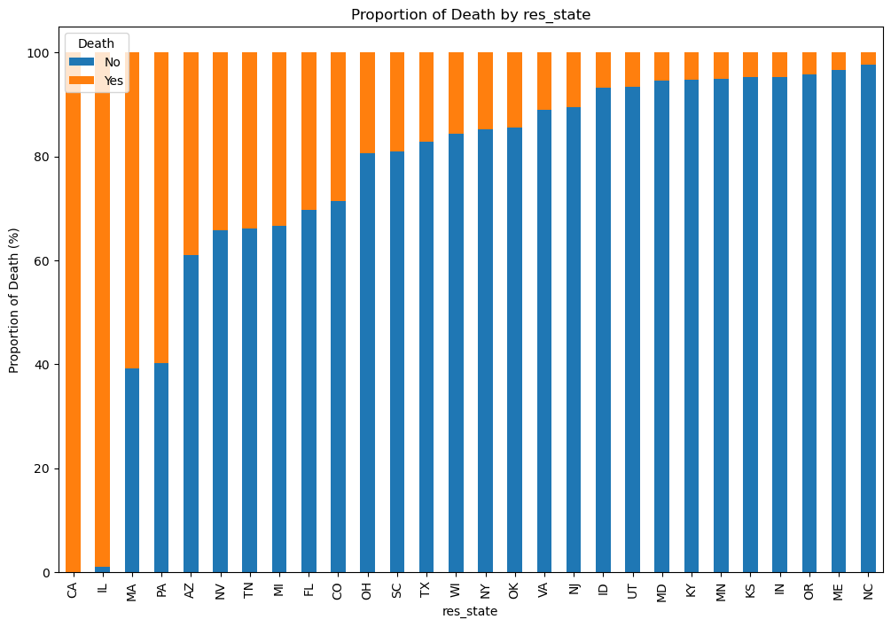

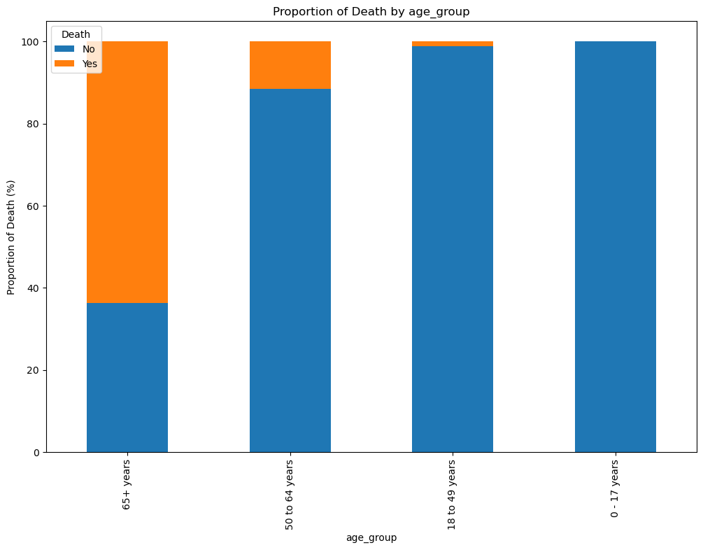

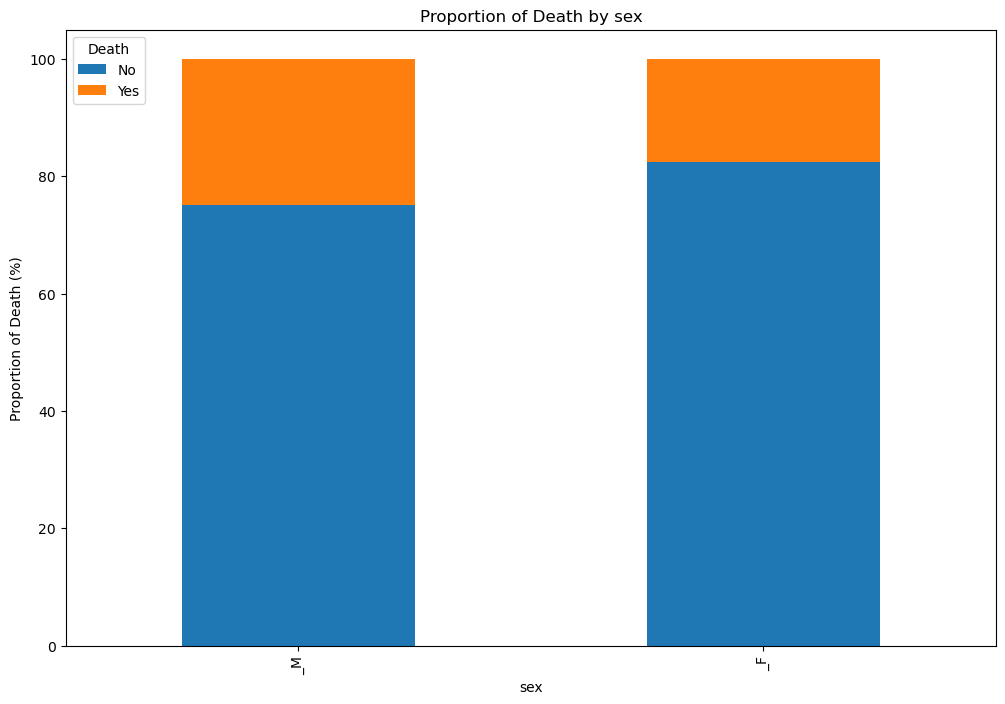

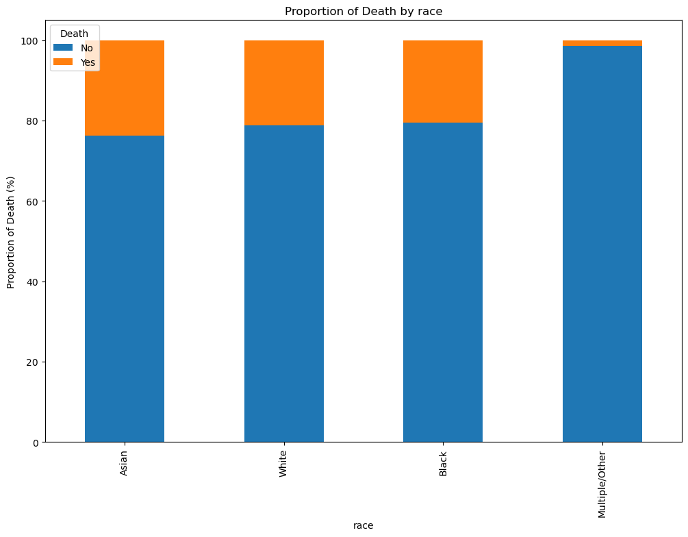

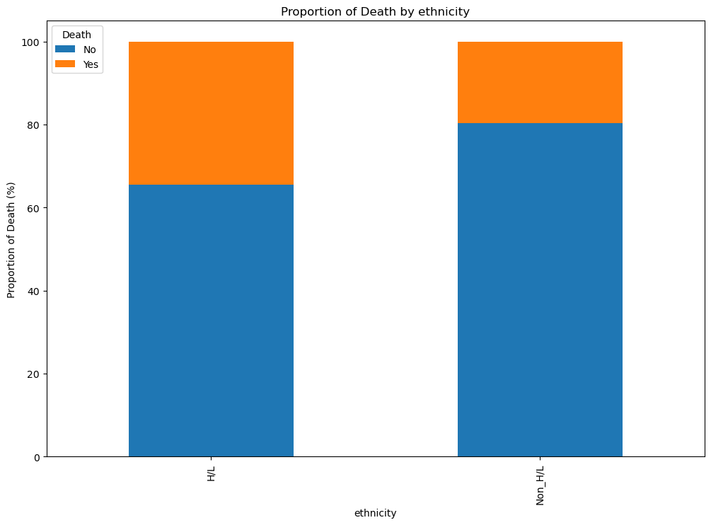

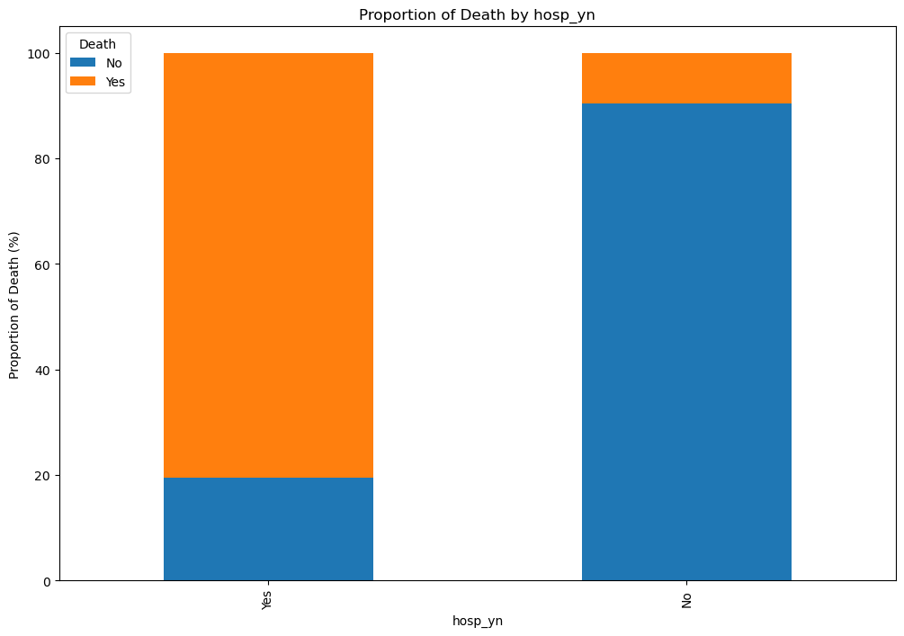

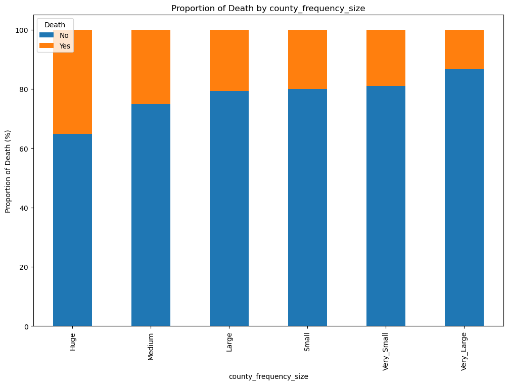

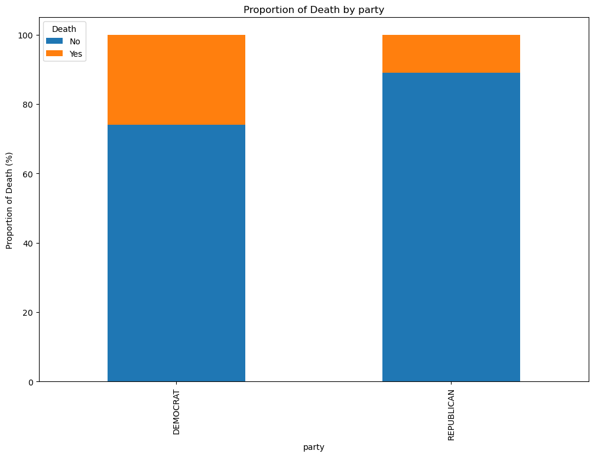

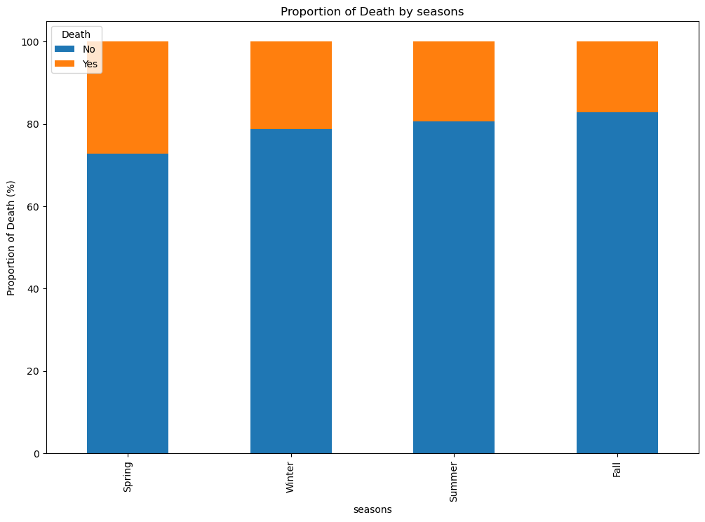

```python
train_data = pd.concat([X_train, y_train], axis=1)

def plot_proportion_of_death(input, feature):
    # Calculate overall counts for each value in the feature
    overall_counts = input[feature].value_counts()

    # Filter features where overall count for any value is greater than 200: allows for better graphing
    valid_features = overall_counts[overall_counts > 200].index.tolist()

    # Calculate counts of 0 and 1 for each feature
    death_counts = input.groupby(feature)['death_yn'].value_counts().unstack(fill_value=0)

    # Filter out only the valid values in the feature
    death_counts = death_counts.loc[valid_features]

    #proportion of death per feature category
    proportion_death_feature = death_counts.div(death_counts.sum(axis=1), axis=0) * 100

    # Sort based on highest death "Yes" proportion
    sorted_feature = proportion_death_feature.sort_values(by=1, ascending=False)

    sorted_feature.plot(kind="bar", stacked=True, figsize=(12, 8))
    plt.title(f"Proportion of Death by {feature}")
    plt.ylabel("Proportion of Death (%)")
    plt.xlabel(feature)
    plt.legend(title="Death", labels=["No", "Yes"], loc='upper left')
    plt.show()

for column in X_train.columns:
    plot_proportion_of_death(train_data, column)
```

- **Discussion of subset of above pairwise interactions between plots:**
- The graphs above contain plots where values for the categories have a count of 200+. This is done in order to improve the legibility of the plots.
- From the plots above age_group and hosp_yn show clear trends, and res_state shows a wide variance, and these seem promising for predicting death_yn.
- **age_group**: The plotted pairwise interaction for age_group confirms suspicions that people 65+ years of age are most at risk of dying from Covid-19, and those aged 0-17 have what appears to be a near total survival rate. Additionally, the trend is present for all 4 values of age_group, 0-17 years, 18-49 years, 50-64 years, and 65+ years. The younger the person is, the more likely they are to survive, possibly due to the robustness of a child's immune system and conversely, older poeple are more susceptible to fatal illness.
- **res_state**: This feature shows a wide degree of outcomes for the target variable. The graph shows 28 states, and there seems to be a roughly 95% variance for predicting the target outcome between the individual States. This appearance should not be chalked down to possible sampling issues, where states with small counts appear to have near 100% survival or fatality rates. On the contrary, the state with the highest death rate is the most populous, California, and the state with the highest survival rate is North Carolina, the 9th largest state in the USA.
- **hosp_yn**: The stacked bar plot of hosp_yn appears to show the most variance and so could be a strong candidate for being able to predict death_yn. Importantly, this feature is a simple boolean, "Was Hospitalised" or "Was Not Hospitalised", and this has the advantages of reduced dimensionality and simplicity. The plot shows that people who were hospitalised are far more likely to pass away as a reuslt of contracting Covid-19. If a patient is hospitalised with Covid-19, their health status is likely to be worse and require treatment, whereas mostly unaffected people have no need of healthcare intervention.

```
- (2.1) On the training set, train a linear regression model to predict the target feature.
- (2.2) Print the coefficients learned by the model
```

```python
preprocessor = ColumnTransformer([
    ('onehot', OneHotEncoder(), X_train.columns)
], remainder='passthrough')

lin_reg = Pipeline([
    ('preprocessor', preprocessor),
    ('model', LinearRegression())
])

lin_reg.fit(X_train, y_train)

features = lin_reg.named_steps['preprocessor'].get_feature_names_out()
features_and_coefficients = list(zip(features, lin_reg.named_steps['model'].coef_))
features_and_coefficients_sorted = sorted(features_and_coefficients, key=lambda x: x[1], reverse=True)

print("Sorted Features and Coefficients by Importance:")
for feature, coefficient in features_and_coefficients_sorted:
    print(feature, coefficient)
```

```
Sorted Features and Coefficients by Importance:
onehot__res_state_AK 0.5081760144527337
onehot__res_state_LA 0.4699106674883572
onehot__res_state_ND 0.4009997479063518
onehot__res_state_MO 0.393863901467838
onehot__res_state_CA 0.3356372810738432
onehot__res_state_IL 0.30154406034954906
onehot__age_group_65+ years 0.27041804695413924
onehot__res_state_WA 0.25182314055362065
onehot__res_state_CT 0.23720121941466846
onehot__res_state_NM 0.22540387096059045
onehot__hosp_yn_Yes 0.1839983292875067
onehot__res_state_GA 0.17058165487890461
onehot__res_state_NE 0.1661381261938041
onehot__res_state_PA 0.12691196163964583
onehot__res_state_MA 0.11438715349317376
onehot__res_state_AL 0.048979464649316524
onehot__res_state_MS 0.03779203375775116
onehot__county_frequency_size_Large 0.0375125791566678
onehot__race_Black 0.030968542152553884
onehot__res_state_AZ 0.030328870759096422
onehot__race_White 0.02219951664422151
onehot__party_REPUBLICAN 0.02041054736410162
onehot__seasons_Spring 0.01732205351867908
onehot__sex__M 0.01311283369255902
onehot__res_state_MI 0.011966807906697902
onehot__ethnicity_H/L 0.01099433248347353
onehot__race_Asian 0.010954319724311178
onehot__county_frequency_size_Medium 0.00974601429625531
onehot__county_frequency_size_Very_Large 0.007338930163383948
onehot__res_state_NV 0.006481196678273006
onehot__seasons_Winter 0.0031621626829800185
onehot__race_American Indian/Alaska Native -0.004672949762018151
onehot__race_Multiple/Other -0.005956492982594053
onehot__county_frequency_size_Small -0.0066783745937401525
onehot__seasons_Summer -0.007931973903787672
onehot__ethnicity_Non_H/L -0.01099433251073193
onehot__seasons_Fall -0.012552242274481568
onehot__sex__F -0.013112833832245867
onehot__county_frequency_size_Very_Small -0.017335498030691465
```

[output cut: 21 more lines]

```
onehot__res_state_MT -0.14875006362687399
onehot__res_state_OR -0.14947499301449843
onehot__res_state_MN -0.15271315948557138
onehot__res_state_OK -0.16321455878727695
onehot__res_state_MD -0.1639815543322579
onehot__res_state_IN -0.1645222973571554
onehot__res_state_UT -0.16525763818946768
onehot__res_state_NJ -0.1753029978186133
onehot__res_state_ID -0.18064915075346635
onehot__hosp_yn_No -0.18399832834116142
onehot__res_state_NC -0.19210237911213807
onehot__res_state_DC -0.19240982750038826
onehot__res_state_KY -0.19878055017672905
onehot__res_state_KS -0.20934200965232233
onehot__res_state_WY -0.2141416045557084
```

- (2.2) Discuss the coefficients role in the model - interpret the model by analysing each coefficient and how it relates each input feature to the target feature.
- Each coefficient represents the change in the target variable (dependent variable) for a one-unit change in the corresponding feature (independent variable), holding all other features constant. A positive coefficient indicates that a this feature is likely to predict death_yes, and a negative coefficient means that death_no is more likely. Understanding these coefficients allows us to interpret how each feature contributes to the model's predictions and provides insights into the relationships between the features and the target variable, death_yn, whose values have been encoded as 0 for No and 1 for Yes.
- Res_state Coefficients: Each coefficient represents the effect of residing in a particular state on target variable death_yn. Positive coefficients indicate that individuals from those states tend to have higher values of the target variable, while negative coefficients suggest lower values. For example, individuals from Alaska (AK) and Louisiana (LA) tend to have a higher value of the target variable compared to the baseline state indicating that these states are strong predictors of the death outcome. Conversely, Wyoming (WY) and Kansas (KS) are poor predictors of the outcome.
- Age_group Coefficients: These coefficients represent the effect of different age groups on the target variable. For instance, the coefficient for the "65+ years" age group is the most positive, and the 7th largest coefficient overall, indicating that individuals in this age group tend to have higher values of the target variable compared to the reference age group.
- Sex, Race, and Ethnicity Coefficients: These coefficients represent the effect of different demographic variables on the target variable. Most of these coefficients lie in the middle, indicating that they are not the best predictors for either death or survival.
- Hospitalization Coefficients: The coefficients for hospitalization indicate the impact of being hospitalized on the target variable. Hosp_yn_Yes Hosp_yn_No lie close to the top and bottom of the coefficient values, indicating they are good predictors of death_yn.
- County_frequency_size Coefficients: These coefficients represent the effect of county size on the target variable, based on the frequenct of cases reported in the dataset - a representation of population. County_frequency_size_Large is the greatest positive coefficient, suggesting that individuals from counties of larger sizes tend to have higher values of the target variable.
- Political Party Coefficients: These coefficients represent the effect of political party affiliation on the target variable. These coefficients are quite small (0.02 and -0.02), indicating they are weak predictors of death_yn.
- Season Coefficients: These coefficients represent the effect of different seasons on the target variable. Much like Party, the encoded features for Season are weak predictors of death_yn.
- (2.3) Print the predicted target feature value for the first 10 training examples.

```python
# Predict target feature values for the training examples
y_train_pred = lin_reg.predict(X_train)

# Threshold the predicted values at 0.5 to obtain predicted classes
y_train_pred_classes = (y_train_pred > 0.5).astype(int)

print("Predicted Classes for the First 10 Examples:")
print(y_train_pred_classes[:10])
```

```
Predicted Classes for the First 10 Examples:
[0 0 0 0 1 0 0 0 0 0]
```

- Anlaysing the data for the first 10 rows, to cross-reference against the class values above.

```python
print("First 10 rows of patients with predicted classes:")
patients_with_classes = X_train.iloc[:10].copy()
patients_with_classes['Predicted_Class'] = y_train_pred_classes[:10]
print(patients_with_classes)
```

```
First 10 rows of patients with predicted classes:
      res_state       age_group sex   race ethnicity hosp_yn  \
36228        IN  50 to 64 years  _M  White   Non_H/L      No
11671        OR  50 to 64 years  _M  White   Non_H/L      No
12993        KY       65+ years  _M  White   Non_H/L      No
17552        MI  50 to 64 years  _M  White   Non_H/L      No
4017         WA       65+ years  _F  White   Non_H/L      No
21542        FL  50 to 64 years  _F  White   Non_H/L      No
27464        MN  18 to 49 years  _M  White   Non_H/L     Yes
34854        NC       65+ years  _F  White   Non_H/L      No
20128        IN    0 - 17 years  _F  White   Non_H/L      No
16270        UT  18 to 49 years  _M  White   Non_H/L      No

      county_frequency_size       party seasons  Predicted_Class
36228            Very_Small  REPUBLICAN  Winter                0
11671                 Small    DEMOCRAT  Winter                0
12993                Medium  REPUBLICAN  Summer                0
17552            Very_Small    DEMOCRAT    Fall                0
4017             Very_Small    DEMOCRAT  Spring                1
21542                 Large    DEMOCRAT  Winter                0
27464                 Large    DEMOCRAT  Summer                0
34854            Very_Large  REPUBLICAN  Winter                0
20128                Medium  REPUBLICAN  Summer                0
16270                 Large  REPUBLICAN    Fall                0
```

- (2.3) Print classification evaluation measures computed on the full training set (Accuracy, Confusion matrix, Precision, Recall, F1)

```python
# Classification evaluation measures
accuracy = accuracy_score(y_train, y_train_pred_classes)
conf_matrix = confusion_matrix(y_train, y_train_pred_classes)
precision = precision_score(y_train, y_train_pred_classes)
recall = recall_score(y_train, y_train_pred_classes)
f1 = f1_score(y_train, y_train_pred_classes)
print("\nClassification Evaluation Measures on Train Set:")
print(f"Accuracy: {accuracy}")
print(f"Confusion Matrix:\n{conf_matrix}")
print(f"Precision: {precision}")
print(f"Recall: {recall}")
print(f"F1 Score: {f1}")
```

```
Classification Evaluation Measures on Train Set:
Accuracy: 0.9276875759959946
Confusion Matrix:
[[21549   551]
 [ 1471  4391]]
Precision: 0.8885066774585189
Recall: 0.7490617536676902
F1 Score: 0.8128470936690114
```

- (2.3) Discuss the findings.
- The model exhibits promising performance in classifying the target variable. The accuracy score of 92.77% indicates that the model correctly predicts the outcome for a vast majority of the instances.
- However, delving deeper into the confusion matrix reveals that there are instances of both false positives (551) and false negatives (1471), suggesting areas for potential improvement.
- Precision, which measures the proportion of true positive predictions among all positive predictions, stands at around 88.85%. This indicates that when the model predicts a positive outcome, it is correct about 88.85% of the time.
- Recall, on the other hand, measures the proportion of true positive predictions among all actual positive instances and is approximately 74.91%, suggesting that the model captures about 74.91% of all actual positive instances.
- The F1 score, a harmonic mean of precision and recall, provides a balanced assessment of the model's performance, yielding a value of about 81.28%. This suggests that the model achieves a good balance between precision and recall.
- Overall, the model demonstrates strong predictive capability, and there is room for fine-tuning to further enhance its performance, particularly in reducing false positives and false negatives.

(2.4) Evaluate the model using classification evaluation measures on the hold-out (30% examples) test set.

```python
y_test_pred = lin_reg.predict(X_test)
y_test_pred_classes = (y_test_pred > 0.5).astype(int)

accuracy_test = accuracy_score(y_test, y_test_pred_classes)
conf_matrix_test = confusion_matrix(y_test, y_test_pred_classes)
precision_test = precision_score(y_test, y_test_pred_classes)
recall_test = recall_score(y_test, y_test_pred_classes)
f1_test = f1_score(y_test, y_test_pred_classes)

print("\nClassification Evaluation Measures on Test Set:")
print(f"Accuracy: {accuracy_test}")
print(f"Confusion Matrix:\n{conf_matrix_test}")
print(f"Precision: {precision_test}")
print(f"Recall: {recall_test}")
print(f"F1 Score: {f1_test}")
```

```
Classification Evaluation Measures on Test Set:
Accuracy: 0.9269086357947435
Confusion Matrix:
[[9230  227]
 [ 649 1879]]
Precision: 0.8922127255460589
Recall: 0.7432753164556962
F1 Score: 0.8109624514458352
```

- (2.4) Compare these results with the evaluation results obtained on the training (70%) dataset:
- The accuracy on the test set (92.69%) is slightly lower than the accuracy on the training set (92.77%), indicating a minor drop in performance when moving from training to test data. This suggests that the model generalizes reasonably well to unseen data.
- The model maintains robustness in classification, as evidenced by the precision, recall, and F1 score metrics. The confusion matrices show similar patterns between the training and test sets, with a higher number of true negatives and true positives compared to false negatives and false positives. Precision, recall, and F1 score are also quite similar between the training and test sets, indicating that the model's performance metrics remain consistent across both datasets.
- Overall, the model appears to perform well and generalize effectively to unseen data, as evidenced by the similar performance metrics between the training and test sets.
- (2.4) Compare training results with a cross-validated model (a new model trained and evaluated using cross-validation on the full dataset).

```python
preprocessor = ColumnTransformer([
    ('onehot', OneHotEncoder(), X.columns)
], remainder='passthrough')
lin_reg = Pipeline([
    ('preprocessor', preprocessor),
    ('model', LinearRegression())
])

# Define cross-validation method
kf = KFold(n_splits=5, shuffle=True, random_state=1)
y_pred_prob_cv = cross_val_predict(lin_reg, X, y, cv=kf, method='predict')
y_pred_class_cv = [1 if prob >= 0.5 else 0 for prob in y_pred_prob_cv]

accuracy_cv = accuracy_score(y, y_pred_class_cv)
precision_cv = precision_score(y, y_pred_class_cv)
recall_cv = recall_score(y, y_pred_class_cv)
f1_cv = f1_score(y, y_pred_class_cv)
print("\nClassification Evaluation Measures on Cross-validated for Linear Regression:")
print("Cross-validated Accuracy:", accuracy_cv)
print("Cross-validated Precision:", precision_cv)
print("Cross-validated Recall:", recall_cv)
print("Cross-validated F1 Score:", f1_cv)
```

```
Classification Evaluation Measures on Cross-validated for Linear Regression:
Cross-validated Accuracy: 0.92705334568303
Cross-validated Precision: 0.8893629124004551
Cross-validated Recall: 0.7454112038140643
Cross-validated F1 Score: 0.8110491505641291
```

- (2.4) Compare the cross-validation metrics to those obtained on the single train/test split and discuss findings:
- Comparing the cross-validation metrics to those obtained on the single train/test split reveals consistent performance of the model across different evaluation methodologies. The cross-validated accuracy, precision, recall, and F1 score metrics are comparable to the results from the single train/test split, indicating robustness and reliability of the model's performance.
- The cross-validated accuracy of 0.9271 and other metrics such as precision, recall, and F1 score align closely with the corresponding metrics from the single train/test split. This consistency suggests that the model's performance is stable and not heavily influenced by the specific train/test split, affirming its generalization capabilities.
- Accuracy: Single train/test split: 0.9269, Cross-validated accuracy: 0.9271.
- Precision: Single train/test split: 0.8922, Cross-validated precision: 0.8894.
- Recall: Single train/test split: 0.7433, Cross-validated recall: 0.7454.
- F1 Score: Single train/test split: 0.8110, Cross-validated F1 score: 0.8110.
- These results indicate that the model's performance remains consistent across different subsets of the data, as evidenced by similar performance metrics between single train/test split and cross-validation.

(3) **Predictive Modeling:** Logistic Regression.

- (3.1) On the training set, train a logistic regression model to predict the target feature
- (3.2) Print the coefficients learned by the model

```python
preprocessor = ColumnTransformer([
    ('onehot', OneHotEncoder(), X_train.columns)
], remainder='passthrough')

log_reg = Pipeline([
    ('preprocessor', preprocessor),
    ('model', LogisticRegression(max_iter=1000)) #was encountering ConvergenceWarning errors, so set mmax_iter=1000
])
log_reg.fit(X_train, y_train)

feature_names = log_reg.named_steps['preprocessor'].get_feature_names_out()
coefficients = log_reg.named_steps['model'].coef_[0]

features_and_coefficients = list(zip(feature_names, coefficients))
sorted_features_and_coefficients = sorted(features_and_coefficients, key=lambda x: x[1], reverse=True)
print("Sorted Features and Coefficients by Importance (highest to lowest):")
for feature, coefficient in sorted_features_and_coefficients:
    print(f"{feature}: {coefficient}")
```

```
Sorted Features and Coefficients by Importance (highest to lowest):
onehot__res_state_CA: 5.442881456348674
onehot__age_group_65+ years: 3.564535723672849
onehot__res_state_IL: 3.5551087369877967
onehot__res_state_MO: 3.3425939791653825
onehot__res_state_LA: 2.8842380368524223
onehot__res_state_WA: 2.3311636180406414
onehot__res_state_NM: 1.939729724620295
onehot__res_state_CT: 1.8925386504851205
onehot__res_state_ND: 1.5219318833706446
onehot__hosp_yn_Yes: 1.3716696320603792
onehot__res_state_AL: 1.3448984109658992
onehot__res_state_GA: 1.2980041338297323
onehot__res_state_MA: 1.0147997151567862
onehot__res_state_PA: 0.939218488805285
onehot__age_group_50 to 64 years: 0.7758874323356896
onehot__res_state_TN: 0.7525202886886709
onehot__res_state_MS: 0.6338064718335605
onehot__res_state_AZ: 0.6264895983920056
onehot__county_frequency_size_Large: 0.6182700248155848
onehot__race_Black: 0.569354785121122
onehot__res_state_AK: 0.5524402381588869
onehot__res_state_NE: 0.5261678404792154
onehot__res_state_NV: 0.409389712843036
onehot__res_state_MI: 0.3702769304479507
onehot__race_White: 0.3638875031689203
onehot__seasons_Spring: 0.34649382293047154
onehot__ethnicity_H/L: 0.33440658961100994
onehot__sex__M: 0.23252129202693794
onehot__county_frequency_size_Very_Large: 0.1864396542386481
onehot__party_DEMOCRAT: 0.15643144135938356
onehot__res_state_NH: 0.13494610361999348
onehot__county_frequency_size_Medium: 0.08473208026036715
onehot__res_state_IA: 0.06293258114211475
onehot__race_Asian: 0.028765054877536094
onehot__seasons_Winter: -0.021466832489389197
onehot__res_state_AR: -0.05025269700334553
onehot__race_Native Hawaiian/Other Pacific Islander: -0.060498795754592265
onehot__res_state_FL: -0.07492214247805348
onehot__res_state_SC: -0.08667809727370902
```

[output cut: 21 more lines]

```
onehot__res_state_OK: -1.0749117671643447
onehot__age_group_18 to 49 years: -1.143749985951999
onehot__res_state_NY: -1.1773364744985333
onehot__res_state_ID: -1.2015498070776571
onehot__hosp_yn_No: -1.3703608190743055
onehot__res_state_ME: -1.8476820391139115
onehot__res_state_KS: -1.909245946702639
onehot__res_state_KY: -1.9928153269818394
onehot__res_state_MD: -2.0731109162706995
onehot__res_state_NC: -2.277198628033649
onehot__res_state_MN: -2.299735442725605
onehot__res_state_OR: -2.3958913390809236
onehot__res_state_DC: -2.4156606727533703
onehot__res_state_NJ: -2.501473868284108
onehot__age_group_0 - 17 years: -3.1953643570704644
```

- (3.2) Discuss the coefficients role in the model - interpret the model by analysing each coefficient and how it relates each input feature to the target feature.
- The coefficients learned by the logistic regression model represent the impact of each feature on the log-odds of the target variable (death outcome in this case). Positive coefficients indicate that as the corresponding feature increases, the log-odds of the target variable (death) increase. Conversely, negative coefficients indicate that as the feature increases, the log-odds of the target variable decrease.
- The highest coefficient, "onehot__res_state_CA" stands out as the most influential feature. A significant positive coefficient of 5.44 suggests that residing in California substantially increases the likelihood of death, making it a high-risk area.
- Following closely, "onehot__age_group_65+ years" exhibits a positive coefficient of 3.56, indicating that individuals aged 65 and above are most at risk compared to other age groups, perhaps due to age-related vulnerabilities. Conversely, the feature "onehot__age_group_0 - 17 years" has the strongest negative coefficient of -3.20, implying a much lower likelihood of death among children and adolescents.
- Sex, Race, Ethnicity: These variables are relatively weak predictors compared to others. In summary: The male coefficient is slightly higher (0.23) than the female coefficient (-0.23). While not among the strongest predictors, it suggests a slight positive association with being male. "Race_Black" and "Race_White" show moderate positive coefficients (0.57 and 0.36, respectively), and "Race_Multiple/Other" stands out with a relatively strong negative coefficient (-0.77), indicating a negative association with the death_yn. Ethnicity-related features have modest coefficients. "Ethnicity_H/L" shows a positive coefficient (0.33).
- Being hospitalized ("hosp_yn_Yes") is a positive predictor (coefficient: 1.37), indicating a higher likelihood of death risk outcome.
- Features related to county frequency size exhibit a range of coefficients. Larger county frequency sizes show positive coefficients, while smaller sizes have negative coefficients. These coefficients suggest varying degrees of association with death_yn based on county size.
- Party-related features ("party_DEMOCRAT" and "party_REPUBLICAN") have relatively weak coefficients, approx (0.16).

```
- (3.3) Print the predicted target feature value for the first 10 training examples.
```

```python
# Predict target feature values for the training examples
y_train_pred = log_reg.predict(X_train)

# Threshold the predicted values at 0.5 to obtain predicted classes
y_train_pred_classes = (y_train_pred > 0.5).astype(int)

print("Predicted Classes for the First 10 Examples:")
print(y_train_pred_classes[:10])
```

```
Predicted Classes for the First 10 Examples:
[0 0 0 0 1 0 0 0 0 0]
```

- (3.3) Print classification evaluation measures computed on the full training set (Accuracy, Confusion matrix, Precision, Recall, F1)

```python
y_train_pred_full = log_reg.predict(X_train)

accuracy_train = accuracy_score(y_train, y_train_pred_full)
conf_matrix_train = confusion_matrix(y_train, y_train_pred_full)
precision_train = precision_score(y_train, y_train_pred_full)
recall_train = recall_score(y_train, y_train_pred_full)
f1_train = f1_score(y_train, y_train_pred_full)

print("\nClassification Evaluation Measures on the full training set:")
print(f"Accuracy: {accuracy_train}")
print(f"Confusion Matrix:\n{conf_matrix_train}")
print(f"Precision: {precision_train}")
print(f"Recall: {recall_train}")
print(f"F1 Score: {f1_train}")
```

```
Classification Evaluation Measures on the full training set:
Accuracy: 0.9338387812030613
Confusion Matrix:
[[21266   834]
 [ 1016  4846]]
Precision: 0.8531690140845071
Recall: 0.8266803138860457
F1 Score: 0.8397158204817189
```

- (3.3) Discuss the findings.
- The Logistic Regression model showcases promising classification performance on the full training set. With an accuracy of approximately 93.38%, the model demonstrates a strong overall ability to correctly classify instances.
- The confusion matrix reveals 21266 true negatives and 4846 true positives, along with 834 false positives and 1016 false negatives, indicating a relatively balanced performance across both classes.
- Precision, which measures the proportion of true positives among all positive predictions, stands at 85.32%, indicating a high precision in identifying positive cases.
- Recall, or the proportion of true positives identified correctly among all actual positives, is also strong at 82.67%, indicating the model's ability to capture a significant portion of positive instances.
- The F1 score, a harmonic mean of precision and recall, further supports the robustness of the model with a value of 83.97%.
- Overall, these evaluation metrics suggest that the logistic regression model has effectively learned patterns in the data, achieving high accuracy and balanced performance in classifying instances, which bodes well for its generalization to unseen data.

(3.4) Evaluate the model using classification evaluation measures on the hold-out (30% examples) test set.

```python
# Evaluate the model on the hold-out test set
y_test_pred = log_reg.predict(X_test)
accuracy_test = accuracy_score(y_test, y_test_pred)
conf_matrix_test = confusion_matrix(y_test, y_test_pred)
precision_test = precision_score(y_test, y_test_pred)
recall_test = recall_score(y_test, y_test_pred)
f1_test = f1_score(y_test, y_test_pred)

print("Classification Evaluation Measures on the Hold-out Test Set:")
print(f"Accuracy: {accuracy_test}")
print("Confusion Matrix:")
print(conf_matrix_test)
print(f"Precision: {precision_test}")
print(f"Recall: {recall_test}")
print(f"F1 Score: {f1_test}")
```

```
Classification Evaluation Measures on the Hold-out Test Set:
Accuracy: 0.9336670838548186
Confusion Matrix:
[[9111  346]
 [ 449 2079]]
Precision: 0.857319587628866
Recall: 0.8223892405063291
F1 Score: 0.8394912174439733
```

- (3.4) Compare these results with the evaluation results obtained on the training (70%) dataset:
- Comparing the evaluation results between the full training set and the hold-out test set reveals consistent performance. On the full training set, the logistic regression model achieved an accuracy of 93.38%, while on the hold-out test set, it attained a slightly lower but still impressive accuracy of 93.37%.
- The confusion matrices for both datasets exhibit similar patterns, with a high number of true negatives and true positives and relatively low numbers of false positives and false negatives.
- Precision scores are also comparable, with values of approximately 85.32% on the training set and 85.73% on the test set, indicating consistent ability to correctly identify positive cases.
- Similarly, recall scores hover around 82.67% on the training set and 82.24% on the test set, suggesting robustness in capturing actual positive instances.
- F1 scores, reflecting the balance between precision and recall, are also consistent, with values of approximately 83.97% on the training set and 83.95% on the test set.
- Overall, these findings suggest that the logistic regression model generalizes well to unseen data, maintaining its strong performance across various evaluation metrics on both the training and test sets.
- (3.4) Compare training results with a cross-validated model (a new model trained and evaluated using cross-validation on the full dataset).

```python
preprocessor = ColumnTransformer([
    ('onehot', OneHotEncoder(), X.columns)
], remainder='passthrough')

log_reg = Pipeline([
    ('preprocessor', preprocessor),
    ('model', LogisticRegression())
])

kf = KFold(n_splits=5, shuffle=True, random_state=1)
y_pred_prob_cv = cross_val_predict(log_reg, X, y, cv=kf, method='predict_proba')[:, 1]
y_pred_class_cv = [1 if prob >= 0.5 else 0 for prob in y_pred_prob_cv]

# Evaluation metrics
accuracy_cv = accuracy_score(y, y_pred_class_cv)
precision_cv = precision_score(y, y_pred_class_cv)
recall_cv = recall_score(y, y_pred_class_cv)
f1_cv = f1_score(y, y_pred_class_cv)
print("\nClassification Evaluation Measures on Cross-validated for Logistic Regression:")
print("Cross-validated Accuracy:", accuracy_cv)
print("Cross-validated Precision:", precision_cv)
print("Cross-validated Recall:", recall_cv)
print("Cross-validated F1 Score:", f1_cv)
```

```
Classification Evaluation Measures on Cross-validated for Logistic Regression:
Cross-validated Accuracy: 0.9330613062307558
Cross-validated Precision: 0.8517971442639094
Cross-validated Recall: 0.8247914183551848
Cross-validated F1 Score: 0.8380767833353517
```

- (3.4) Compare the cross-validation metrics to those obtained on the single train/test split and discuss findings:
- In comparing the cross-validated model with the single train/test split results, we observe negligible differences between the two.
- The single train/test split yielded an accuracy of 93.38%, while the cross-validated model achieved a slightly lower accuracy of 93.31%. Precision and recall metrics also exhibit minor variations, with precision at 85.32% in the single train/test split and 85.18% in the cross-validated model, and recall at 82.67% and 82.48%, respectively. Additionally, the F1 score for the single train/test split was 83.97%, marginally higher than the cross-validated model's 83.81%.
- The small discrepancies suggest that the model's performance remains consistent between the single train/test split and cross-validation. The cross-validated model's metrics closely align with those obtained from the single train/test split, validating the model's stability and reliability in predicting outcomes across different subsets of the dataset. Overall, both evaluation approaches affirm the robustness and generalization capacity of the logistic regression model.

(4) **Predictive Modeling:** Random Forest.

```
- (4.1) On the training set, train a random forest model to predict the target feature,
```

```python
encoder = OneHotEncoder()
X_train_encoded = encoder.fit_transform(X_train)
X_test_encoded = encoder.transform(X_test)

rf_classifier = RandomForestClassifier(random_state=1)
rf_classifier.fit(X_train_encoded, y_train)

y_train_pred = rf_classifier.predict(X_train_encoded)

accuracy_train = accuracy_score(y_train, y_train_pred)
conf_matrix_train = confusion_matrix(y_train, y_train_pred)
precision_train = precision_score(y_train, y_train_pred)
recall_train = recall_score(y_train, y_train_pred)
f1_train = f1_score(y_train, y_train_pred)

print("\nClassification Evaluation Measures on the full training set:")
print(f"Accuracy: {accuracy_train}")
print(f"Confusion Matrix:\n{conf_matrix_train}")
print(f"Precision: {precision_train}")
print(f"Recall: {recall_train}")
print(f"F1 Score: {f1_train}")
```

```
Classification Evaluation Measures on the full training set:
Accuracy: 0.9597310635862957
Confusion Matrix:
[[21526   574]
 [  552  5310]]
Precision: 0.9024473147518695
Recall: 0.9058341862845445
F1 Score: 0.9041375787502128
```

```python
print("Predicted target feature values for the first 10 training examples:")
print(y_train_pred[:10])

print("\nPredicted class for the first 10 training examples:")
predicted_classes = ['No' if pred == 0 else 'Yes' for pred in y_train_pred[:10]]
print(predicted_classes)
```

```
Predicted target feature values for the first 10 training examples:
[0 0 0 0 1 0 0 0 0 0]

Predicted class for the first 10 training examples:
['No', 'No', 'No', 'No', 'Yes', 'No', 'No', 'No', 'No', 'No']
```

- (4.4) Evaluate the model using classification evaluation measures on the hold-out (30% examples) test set.

```python
y_test_pred = rf_classifier.predict(X_test_encoded)

accuracy_test = accuracy_score(y_test, y_test_pred)
conf_matrix_test = confusion_matrix(y_test, y_test_pred)
precision_test = precision_score(y_test, y_test_pred)
recall_test = recall_score(y_test, y_test_pred)
f1_test = f1_score(y_test, y_test_pred)

print("\nClassification Evaluation Measures on the hold-out test set:")
print(f"Accuracy: {accuracy_test}")
print(f"Confusion Matrix:\n{conf_matrix_test}")
print(f"Precision: {precision_test}")
print(f"Recall: {recall_test}")
print(f"F1 Score: {f1_test}")
```

```
Classification Evaluation Measures on the hold-out test set:
Accuracy: 0.9336670838548186
Confusion Matrix:
[[9069  388]
 [ 407 2121]]
Precision: 0.8453567158230371
Recall: 0.839003164556962
F1 Score: 0.8421679571173318
```

```python
rf_classifier_cv = RandomForestClassifier(random_state=1)
X_encoded = encoder.transform(X)

k_fold = KFold(n_splits=5, shuffle=True, random_state=1)
cv_scores = cross_val_score(rf_classifier_cv, X_encoded, y, cv=k_fold, scoring='accuracy')
print("\nCross-Validated Accuracy:", cv_scores.mean())
accuracy = cv_scores.mean()
out_of_sample_error = 1 - accuracy
print("Out-of-sample error:", out_of_sample_error)

rf_classifier_cv.fit(X_encoded, y)
y_pred_cv = rf_classifier_cv.predict(X_encoded)

accuracy_cv = accuracy_score(y, y_pred_cv)
conf_matrix_cv = confusion_matrix(y, y_pred_cv)
precision_cv = precision_score(y, y_pred_cv)
recall_cv = recall_score(y, y_pred_cv)
f1_cv = f1_score(y, y_pred_cv)

print("\nClassification Evaluation Measures on the full dataset using Cross-Validation for Random Forest:")
print(f"Accuracy: {accuracy_cv}")
print(f"Confusion Matrix:\n{conf_matrix_cv}")
print(f"Precision: {precision_cv}")
print(f"Recall: {recall_cv}")
print(f"F1 Score: {f1_cv}")
```

```
Cross-Validated Accuracy: 0.9371668177661681
Out-of-sample error: 0.06283318223383194

Classification Evaluation Measures on the full dataset using Cross-Validation for Random Forest:
Accuracy: 0.9566675845495282
Confusion Matrix:
[[30625   932]
 [  799  7591]]
Precision: 0.890648832570691
Recall: 0.9047675804529202
F1 Score: 0.8976526931945841
```

```python
majority_class_count = len(df[df['death_yn'] == "No"])
total_instances = len(df)

# Proportion of 'no' instances (majority class)
proportion_majority_class = majority_class_count / total_instances

# Accuracy of the majority class baseline model
accuracy_majority_class_baseline = proportion_majority_class

# Confusion Matrix for Random Forest
true_negatives = 30625
false_positives = 932
true_positives = 7591
false_negatives = 799

# Total instances
total_instances = true_negatives + false_positives + true_positives + false_negatives

# Accuracy of the Random Forest model
accuracy_random_forest = (true_positives + true_negatives) / total_instances

print("Accuracy of Random Forest:", accuracy_random_forest)
print("Accuracy of Majority Class Baseline Model:", accuracy_majority_class_baseline)

if accuracy_random_forest > accuracy_majority_class_baseline:
    print("Random Forest model is more accurate than the majority class baseline model.")
else:
    print("Random Forest model is not more accurate than the majority class baseline model.")
```

```
Accuracy of Random Forest: 0.9566675845495282
Accuracy of Majority Class Baseline Model: 0.7899717125190878
Random Forest model is more accurate than the majority class baseline model.
```

```python
encoder = OneHotEncoder()
X_train_encoded = encoder.fit_transform(X_train)
X_test_encoded = encoder.transform(X_test)
```

```python
results = []
for n_features in range(5, 76, 5):  # Start from 5 and increment by 5 up to 75
    # Initialize RFE with the current number of features to select
    selector = RFE(estimator=RandomForestClassifier(random_state=1), n_features_to_select=n_features)

    # Perform feature selection on the encoded training data
    X_train_selected = selector.fit_transform(X_train_encoded, y_train)

    # Transform the encoded test data based on the selected features
    X_test_selected = selector.transform(X_test_encoded)

    # Initialize and train Random Forest Classifier on the selected features
    rf_classifier = RandomForestClassifier(random_state=1)
    rf_classifier.fit(X_train_selected, y_train)

    # Make predictions on the test data with selected features
    rf_predictions = rf_classifier.predict(X_test_selected)

    # Calculate accuracy for the current number of selected features
    accuracy = accuracy_score(y_test, rf_predictions)

    # Append the results
    results.append((n_features, accuracy))

# Print the results
print("Number of Features | Accuracy")
for n_features, accuracy in results:
    print(f"{n_features:17} | {accuracy:.4f}")
```

```
Number of Features | Accuracy
                5 | 0.9028
               10 | 0.9098
               15 | 0.9232
               20 | 0.9234
               25 | 0.9225
               30 | 0.9246
               35 | 0.9282
               40 | 0.9290
               45 | 0.9320
               50 | 0.9322
               55 | 0.9323
               60 | 0.9333
               65 | 0.9341
               70 | 0.9336
               75 | 0.9337
```

- Results of Model Evaluation using Recursive Feature Elimination (RFE) with Random Forest Classifier:

No. Features Accuracy 5 0.9028 10 0.9098 15 0.9232 20 0.9234 25 0.9225 30 0.9246 35 0.9282 40 0.9290 45 0.9320 50 0.9322 55 0.9323 60 0.9333 65 0.9341 70 0.9336 75 0.9337

-These findings highlight the importance of feature selection in optimizing model performance, ensuring both accuracy and efficiency.

- Approach 2: Reducing Multicollinearity through Correlation Matrix, Building on the Above Findings from Approach 1.
- By identifying correlations between categorical variables and selecting those most strongly associated with "death_yn," we can mitigate multicollinearity, streamlining the model. This refined approach enhances predictive accuracy for mortality outcomes. Simplifying the model through high-correlation feature selection optimizes its efficacy, offering valuable insights into mortality prediction.

```python
categorical_data = df.select_dtypes(include='category')

# Compute the correlation matrix using eta correlation coefficient
correlation_matrix = pd.DataFrame(index=categorical_data.columns, columns=categorical_data.columns)
for col1 in categorical_data.columns:
    for col2 in categorical_data.columns:
        if col1 == col2:
            correlation_matrix.loc[col1, col2] = 1.0
        else:
            confusion_matrix = pd.crosstab(categorical_data[col1], categorical_data[col2])
            chi2, _, _, _ = stats.chi2_contingency(confusion_matrix)
            n = confusion_matrix.sum().sum()
            phi2 = chi2 / n
            r = min(confusion_matrix.shape[0], confusion_matrix.shape[1]) - 1
            correlation_matrix.loc[col1, col2] = (phi2 / r) ** 0.5

print("Correlation Matrix (Eta correlation coefficient):")
print(correlation_matrix)
```

```
Correlation Matrix (Eta correlation coefficient):
                      res_state age_group       sex      race ethnicity  \
res_state                   1.0  0.230085  0.076771   0.14921  0.375716
age_group              0.230085       1.0  0.066215  0.050763  0.013109
sex                    0.076771  0.066215       1.0  0.033059  0.023184
race                    0.14921  0.050763  0.033059       1.0  0.112771
ethnicity              0.375716  0.013109  0.023184  0.112771       1.0
hosp_yn                0.394933  0.481876  0.078712  0.049926   0.09845
death_yn               0.568582  0.682257  0.089431  0.049988  0.096965
county_frequency_size  0.436491  0.061653  0.030647  0.093477  0.265068
party                       1.0  0.114838  0.031082  0.058202   0.14724
seasons                0.226746  0.037001  0.009251  0.055699  0.063098

                        hosp_yn  death_yn county_frequency_size     party  \
res_state              0.394933  0.568582              0.436491       1.0
age_group              0.481876  0.682257              0.061653  0.114838
sex                    0.078712  0.089431              0.030647  0.031082
race                   0.049926  0.049988              0.093477  0.058202
ethnicity               0.09845  0.096965              0.265068   0.14724
hosp_yn                     1.0  0.636812              0.114273    0.1456
death_yn               0.636812       1.0              0.138616  0.172211
county_frequency_size  0.114273  0.138616                   1.0  0.296168
party                    0.1456  0.172211              0.296168       1.0
seasons                0.089708  0.080282              0.090299  0.162968

                        seasons
res_state              0.226746
age_group              0.037001
sex                    0.009251
race                   0.055699
ethnicity              0.063098
hosp_yn                0.089708
death_yn               0.080282
county_frequency_size  0.090299
party                  0.162968
seasons                     1.0
```

- Pairs with relatively high correlation coefficients:

age_group and death_yn: 0.682 res_state and death_yn: 0.569 hosp_yn and death_yn: 0.637

- Limiting the predictor variables to age_group, res_state, and hosp_yn, and we can still facilitate the prediction of death_yn with some accuracy, yet with a simplified model.
- By retaining these variables, we focus on essential predictors while mitigating multicollinearity concerns. Age_group provides demographic information, res_state offers geographical context, and hosp_yn indicates hospitalization status.

```python
# Select predictor variables and target variable
X = df[['age_group', 'res_state', 'hosp_yn']]
y = df['death_yn'].replace({'Yes': 1, 'No': 0})

X_train, X_test, y_train, y_test = train_test_split(X, y, test_size=0.3, random_state=1)

encoder = OneHotEncoder()
X_train_encoded = encoder.fit_transform(X_train)
X_test_encoded = encoder.transform(X_test)

rf_classifier = RandomForestClassifier(random_state=1)
rf_classifier.fit(X_train_encoded, y_train)
y_train_pred = rf_classifier.predict(X_train_encoded)

accuracy_train = accuracy_score(y_train, y_train_pred)
conf_matrix_train = confusion_matrix(y_train, y_train_pred)
precision_train = precision_score(y_train, y_train_pred)
recall_train = recall_score(y_train, y_train_pred)
f1_train = f1_score(y_train, y_train_pred)

print("\nClassification Evaluation Measures on the full training set:")
print(f"Accuracy: {accuracy_train}")
print(f"Confusion Matrix:\n{conf_matrix_train}")
print(f"Precision: {precision_train}")
print(f"Recall: {recall_train}")
print(f"F1 Score: {f1_train}")
```

```
Classification Evaluation Measures on the full training set:
Accuracy: 0.9368786209856234
Confusion Matrix:
[[21154   946]
 [  819  5043]]
Precision: 0.8420437468692603
Recall: 0.8602865916069601
F1 Score: 0.8510674204708465
```

```python
y_test_pred = rf_classifier.predict(X_test_encoded)

accuracy_test = accuracy_score(y_test, y_test_pred)
conf_matrix_test = confusion_matrix(y_test, y_test_pred)
precision_test = precision_score(y_test, y_test_pred)
recall_test = recall_score(y_test, y_test_pred)
f1_test = f1_score(y_test, y_test_pred)

print("\nClassification Evaluation Measures on the test set:")
print(f"Accuracy: {accuracy_test}")
print(f"Confusion Matrix:\n{conf_matrix_test}")
print(f"Precision: {precision_test}")
print(f"Recall: {recall_test}")
print(f"F1 Score: {f1_test}")
```

```
Classification Evaluation Measures on the test set:
Accuracy: 0.9345848977889027
Confusion Matrix:
[[9063  394]
 [ 390 2138]]
Precision: 0.844391785150079
Recall: 0.8457278481012658
F1 Score: 0.8450592885375493
```

```python
rf_classifier_cv = RandomForestClassifier(random_state=1)
X_encoded = encoder.transform(X)

k_fold = KFold(n_splits=5, shuffle=True, random_state=1)
cv_scores = cross_val_score(rf_classifier_cv, X_encoded, y, cv=k_fold, scoring='accuracy')
print("\nCross-Validated Accuracy:", cv_scores.mean())
accuracy = cv_scores.mean()
out_of_sample_error = 1 - accuracy
print("Out-of-sample error:", out_of_sample_error)

rf_classifier_cv.fit(X_encoded, y)
y_pred_cv = rf_classifier_cv.predict(X_encoded)

accuracy_cv = accuracy_score(y, y_pred_cv)
conf_matrix_cv = confusion_matrix(y, y_pred_cv)
precision_cv = precision_score(y, y_pred_cv)
recall_cv = recall_score(y, y_pred_cv)
f1_cv = f1_score(y, y_pred_cv)

print("\nClassification Evaluation Measures on the full dataset using Cross-Validation for Random Forest:")
print(f"Accuracy: {accuracy_cv}")
print(f"Confusion Matrix:\n{conf_matrix_cv}")
print(f"Precision: {precision_cv}")
print(f"Recall: {recall_cv}")
print(f"F1 Score: {f1_cv}")
```

```
Cross-Validated Accuracy: 0.9348637041764718
Out-of-sample error: 0.0651362958235282

Classification Evaluation Measures on the full dataset using Cross-Validation for Random Forest:
Accuracy: 0.9364407840388514
Confusion Matrix:
[[30215  1342]
 [ 1197  7193]]
Precision: 0.8427650849443468
Recall: 0.8573301549463648
F1 Score: 0.8499852289512556
```